# Working with models

Andrew Irwin

2026-02-09

In this demonstration, we will practice adding smooths (regression lines) to plots, including using colour and facets to create multiple lines.

## Life expectancy by year

Plot life expectancy by year, facet on continent, add regression line by continent, show a thin line for each country. Possibly show a regression line for each country instead of data.

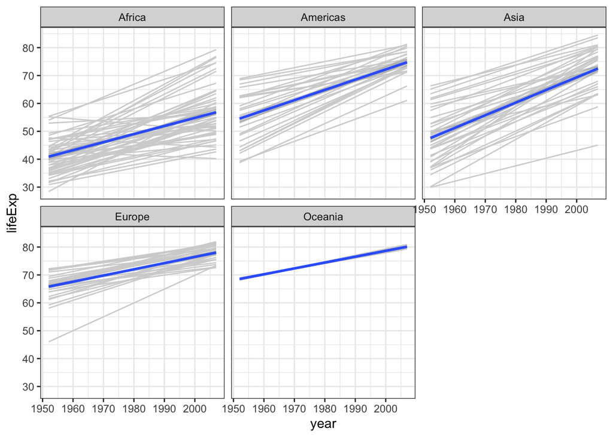

```r
gapminder |> ggplot(aes(x = year, y = lifeExp)) +
  # geom_point() +
  facet_wrap(~ continent) +
  geom_smooth(method = "lm", formula = y ~ x, aes(group = country), se = FALSE,
              linewidth = 0.5, color = "lightgray", alpha = 0.1) +
  geom_smooth(method = "lm", formula = y ~ x) +
  theme_bw()
```

## Quantile regression

Use `geom_quantile` and `quantiles = ...` to do quantile regression. Try a polynomial instead of a straight line.

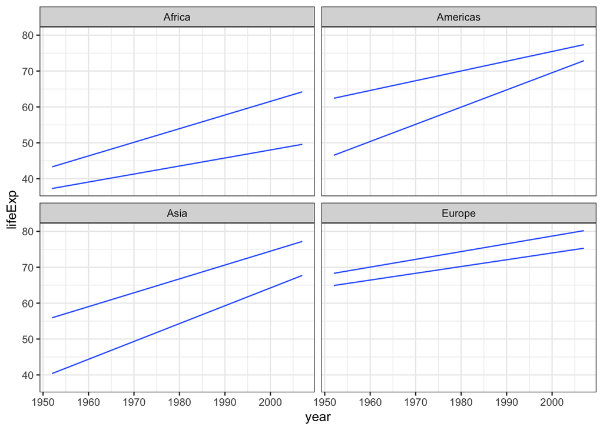

```r
gapminder |> filter(continent != "Oceania") |>
  ggplot(aes(x = year, y = lifeExp)) +
  # geom_point(alpha = 0.25) +
  facet_wrap(~ continent) +
  geom_quantile(method = "rqss", formula = y ~ x, quantiles = c(0.25, 0.75)) +
  theme_bw()
```

```r
# ignore harmless warning messages
```

## Logarithmic increases

Show increase in life expectancy as a function of GDP per capita. Add an appropriate regression line.

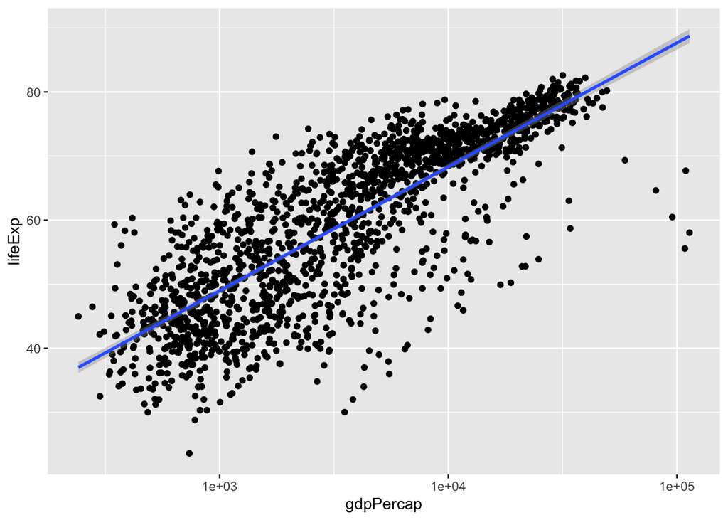

```r
gapminder |> ggplot(aes(gdpPercap, lifeExp)) +
  geom_point() +
  geom_smooth(method = "lm", formula = y ~ x) +
  scale_x_log10()
```

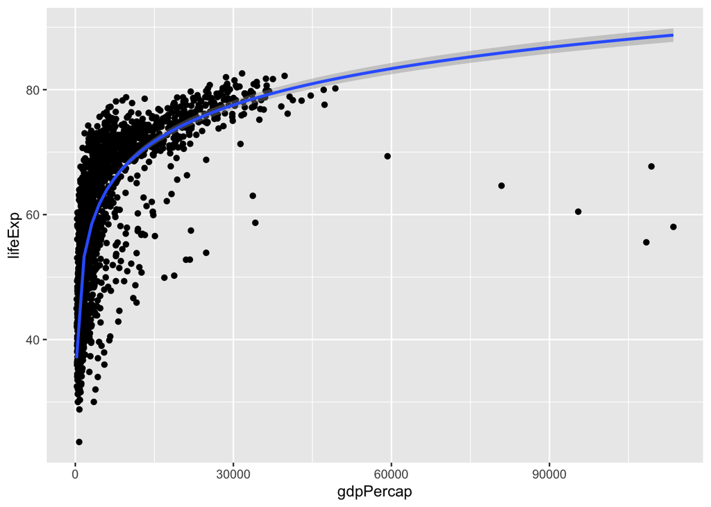

```r
gapminder |> ggplot(aes(gdpPercap, lifeExp)) +
  geom_point() +
  geom_smooth(method = "lm", formula = y ~ log(x))
```

Compare regression on the mean (ordinary least squares, linear model, lm) with quantile regression on the median (geom_quantile, quantiles = 0.5).

## CO2

Plot full data and add a smooth.

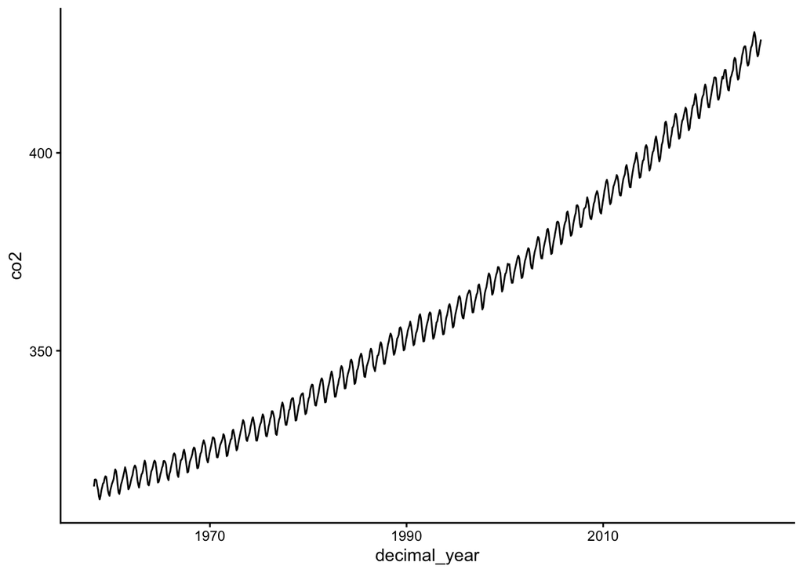

```r
co2 <- read_table("https://www.esrl.noaa.gov/gmd/webdata/ccgg/trends/co2/co2_mm_mlo.txt",
                  comment = "#", col_names = FALSE, show_col_types = FALSE) |>
  rename(year = X1,
         decimal_year = X3,
         co2 = X4)
co2 |> ggplot(aes(decimal_year, co2)) + geom_line() + theme_classic()
```

Show interannual cycle for CO2 after subtracting annual mean, plot as a function of the fraction of the year elapsed, smooth with a LOESS or GAM.

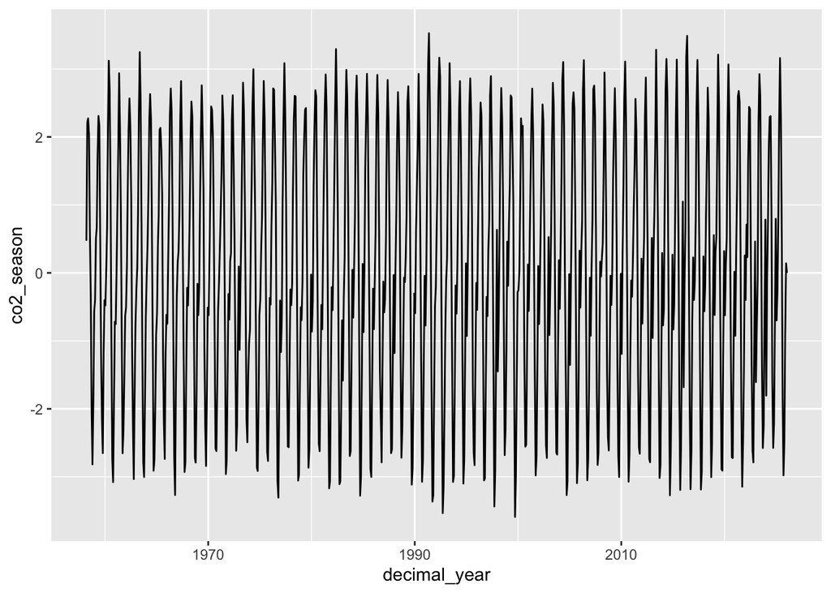

```r
co2 |> group_by(year) |>
  mutate(annual_mean = mean(co2),
         co2_season = co2 - annual_mean) |>
  ggplot(aes(decimal_year, co2_season)) +
  geom_line()
```

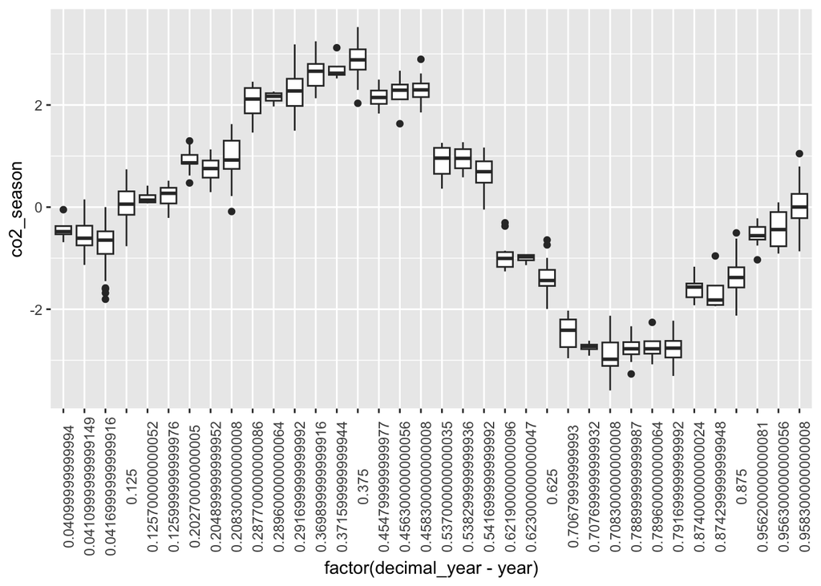

```r
co2 |> group_by(year) |>
  mutate(annual_mean = mean(co2),
         co2_season = co2 - annual_mean) |>
  ggplot(aes(factor(decimal_year - year), co2_season)) +
  geom_boxplot() +
  theme(axis.text.x.bottom = element_text(angle = 90))
```

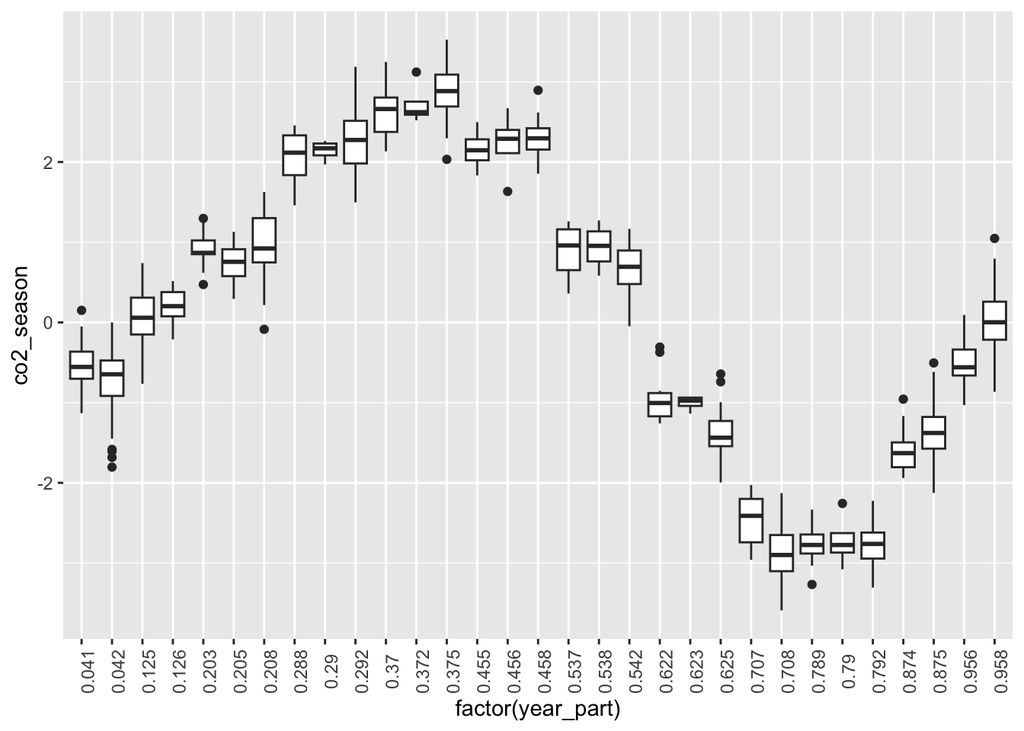

```r
co2 |> group_by(year) |>
  mutate(annual_mean = mean(co2),
         co2_season = co2 - annual_mean,
         year_part = round(decimal_year - year, 3)) |>
  ggplot(aes(factor(year_part), co2_season)) +
  geom_boxplot() +
  theme(axis.text.x.bottom = element_text(angle = 90))
```

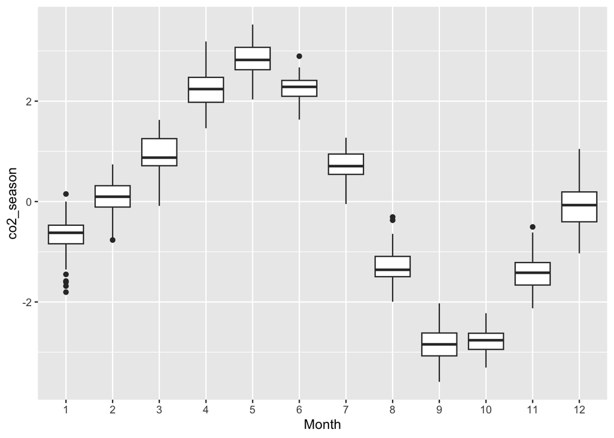

```r
co2 |> group_by(year) |>
  mutate(annual_mean = mean(co2),
         co2_season = co2 - annual_mean) |>
  ggplot(aes(factor(X2) , co2_season)) +
  geom_boxplot()  + labs(x = "Month")
```

Add a periodic GAM to the CO2 data.

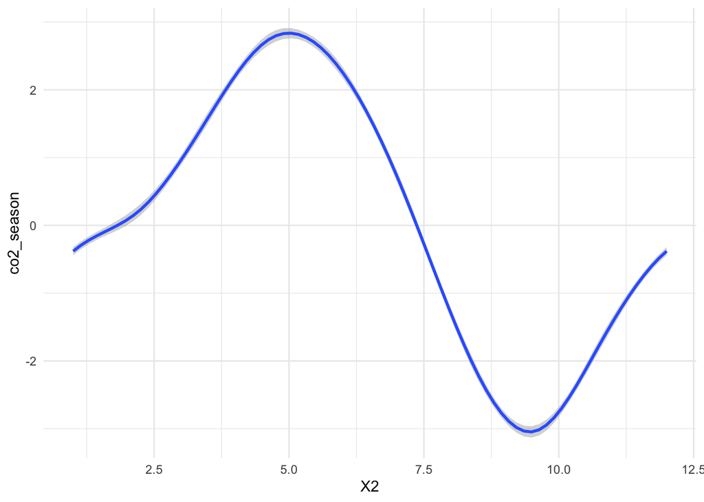

```r
co2 |> group_by(year) |>
  mutate(annual_mean = mean(co2),
         co2_season = co2 - annual_mean) |>
  ggplot(aes(X2, co2_season)) +
  geom_smooth(method = "gam", formula = y ~ s(x, bs = "cc")) + # try basis (bs) = cc, cs
  theme_minimal()
```

Facet by decade

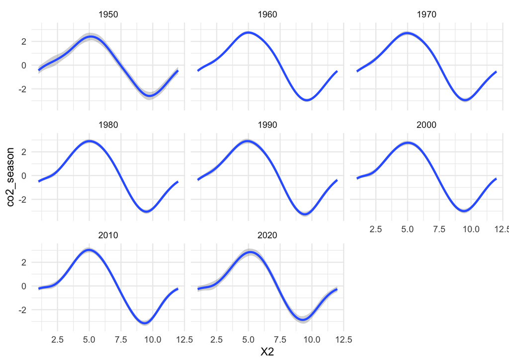

```r
co2 |> group_by(year) |>
  mutate(annual_mean = mean(co2),
         co2_season = co2 - annual_mean,
         decade = 10 * floor(year/10)) |>
  ggplot(aes(X2, co2_season)) +
  geom_smooth(method = "gam", formula = y ~ s(x, bs = "cc")) + # try basis (bs) = cc, cs
  facet_wrap(~ decade) +
  theme_minimal()
```

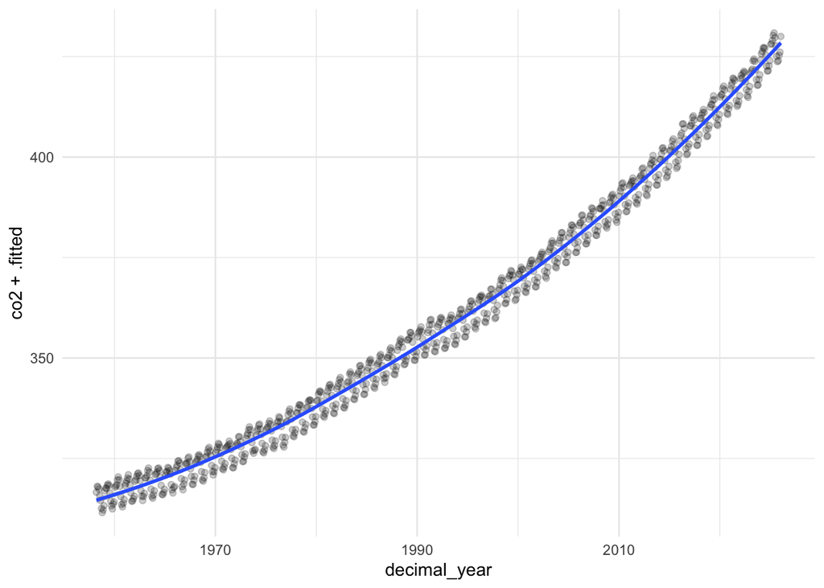

```r
co2_improved <- co2 |> group_by(year) |>
  mutate(annual_mean = mean(co2),
         co2_season = co2 - annual_mean)
m1 <- gam(co2_season ~ X2, data = co2_improved)
augment(m1, co2_improved) |>
  # ggplot(aes(decimal_year, X5)) +
  ggplot(aes(decimal_year, co2 + .fitted)) +
  geom_point(alpha = 0.2) +
  geom_smooth(method = "loess", formula = y ~ x) + # try basis (bs) = cc, cs
  theme_minimal()
```

Try some boxplots, facet by decade, other variations.

## Examples from previous year

### Life expectancy by year

Build up a complex plot piece by piece.

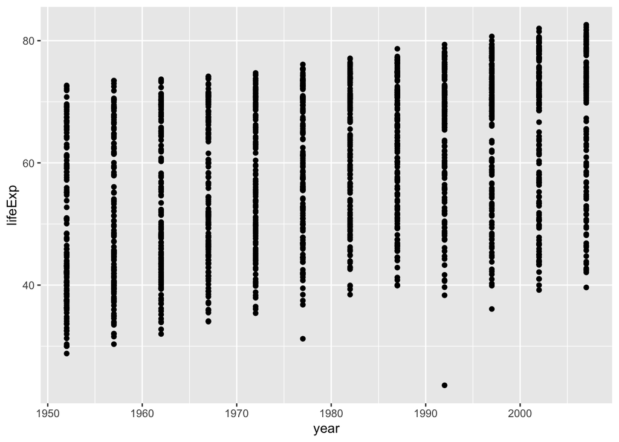

```r
gapminder |> ggplot(aes(year, lifeExp)) + geom_point()
```

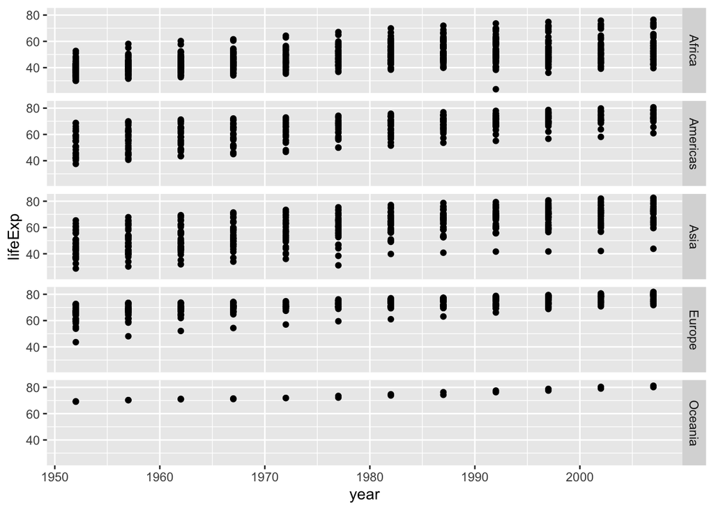

```r
gapminder |> ggplot(aes(year, lifeExp)) + geom_point() +
  facet_grid(continent ~ .)
```

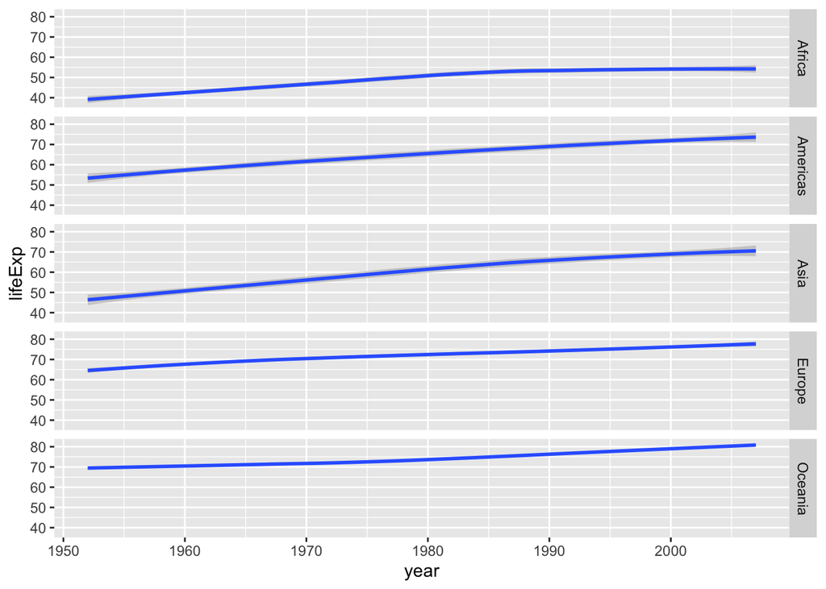

```r
gapminder |> ggplot(aes(year, lifeExp)) +
  geom_smooth() +
  facet_grid(continent ~ .)
```

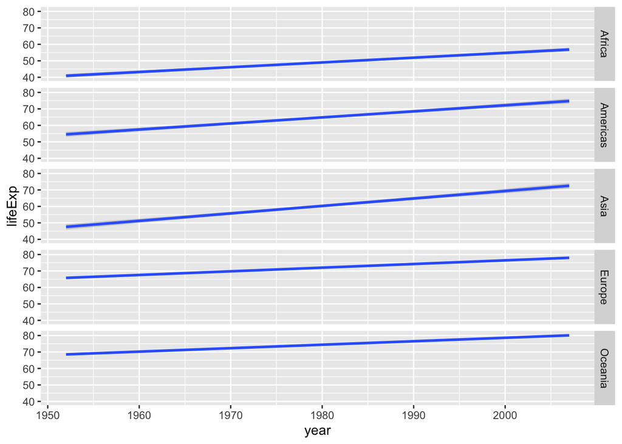

```r
gapminder |> ggplot(aes(year, lifeExp)) +
  geom_smooth(method = "lm") +
  facet_grid(continent ~ .)
```

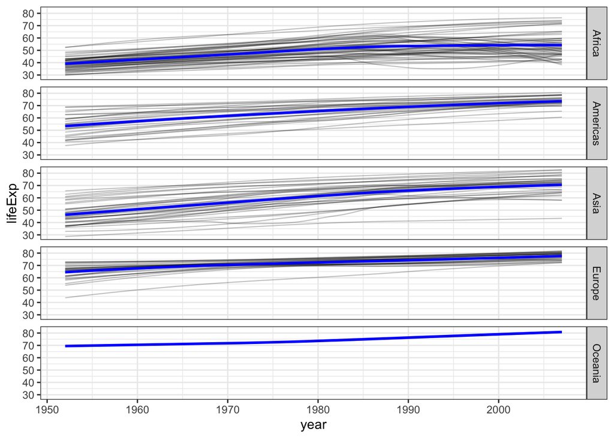

```r
gapminder |> ggplot(aes(year, lifeExp)) +
  geom_smooth(aes(group = country), se = FALSE, color = "#00000040", size = 0.4) +
  geom_smooth(color = "blue") +
  facet_grid(continent ~ .) +
  theme_bw()
```

Quantile regression

```
## Smoothing formula not specified. Using: y ~ x
```

```
## Smoothing formula not specified. Using: y ~ x
## Smoothing formula not specified. Using: y ~ x
## Smoothing formula not specified. Using: y ~ x
## Smoothing formula not specified. Using: y ~ x
```

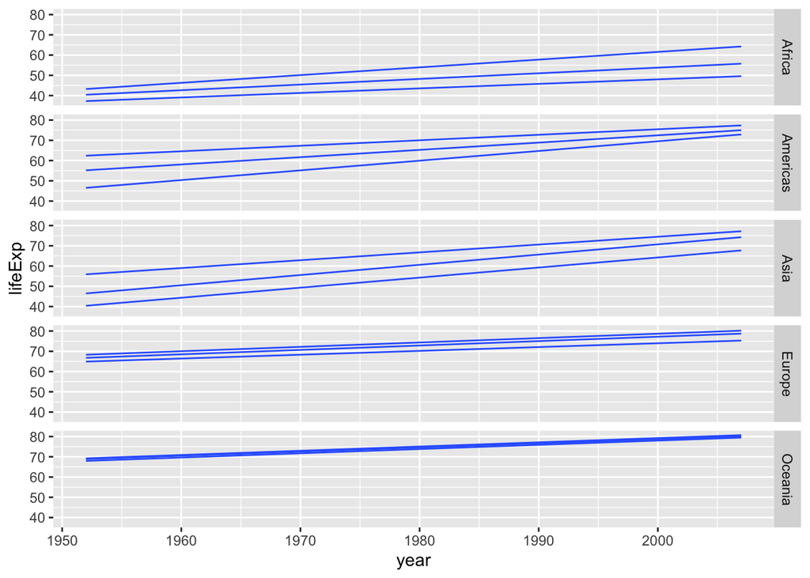

```r
gapminder |> ggplot(aes(year, lifeExp)) +
  geom_quantile() +
  facet_grid(continent ~ .)
```

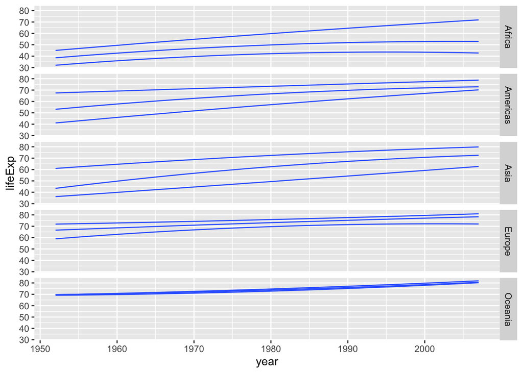

```r
gapminder |> ggplot(aes(year, lifeExp)) +
  geom_quantile(quantiles = c(0.1, 0.5, 0.9), formula = y ~ poly(x,2)) +
  facet_grid(continent ~ .)
```

Compare regression on the mean (ordinary least squares, linear model, lm) with quantile regression on the median (tau = 0.5).

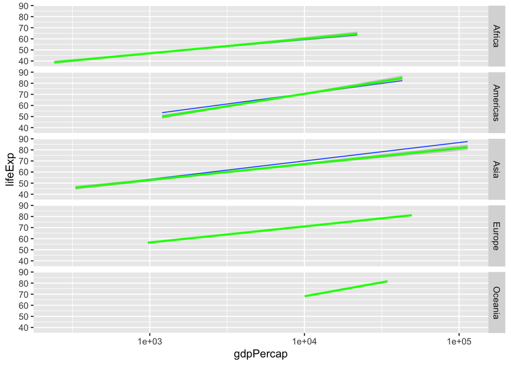

```r
gapminder |>
  # filter(continent %in% c("Africa", "Americas", "Asia")) |>
  ggplot(aes(gdpPercap, lifeExp)) +
  scale_x_log10() +
  geom_quantile(quantiles = 0.5, formula = y ~ x) +
  geom_smooth(method = "lm", formula = y ~ x, color = "green") +
  facet_grid(continent ~ .)
```

```r
  # facet_wrap(continent ~ ., ncol=1)
```

### CO2

Get data from previous lesson (reading data):

```r
co2 <- read_table("https://www.esrl.noaa.gov/gmd/webdata/ccgg/trends/co2/co2_mm_mlo.txt",
                  comment = "#", col_names = FALSE)
```

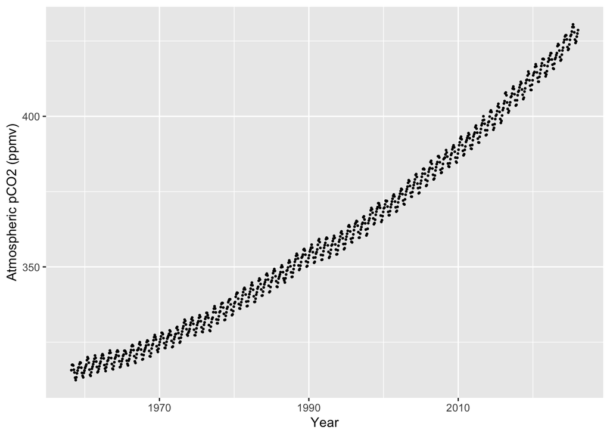

```r
co2 |> ggplot(aes(X3, X4)) + geom_point(size = 0.4) +
  labs(x = "Year", y = "Atmospheric pCO2 (ppmv)")
```

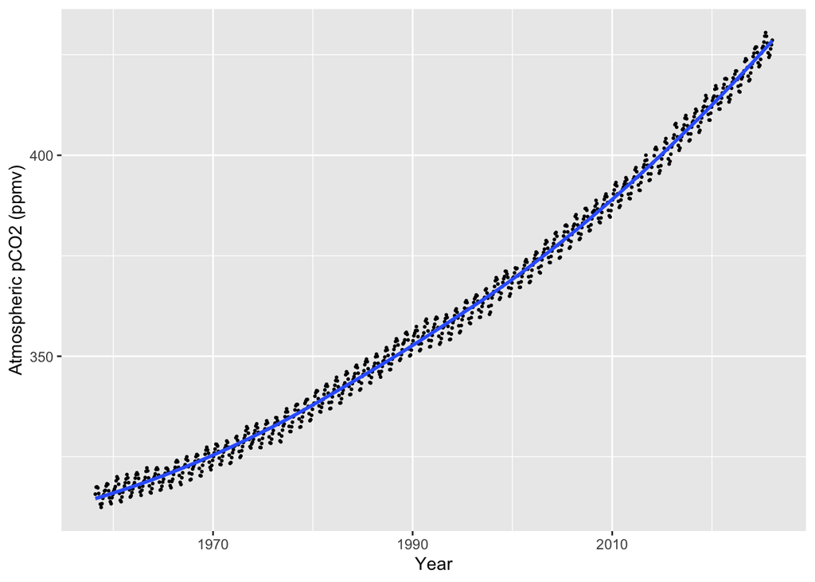

```r
co2 |> ggplot(aes(X3, X4)) + geom_point(size = 0.4) +
  geom_smooth() +
  labs(x = "Year", y = "Atmospheric pCO2 (ppmv)")
```

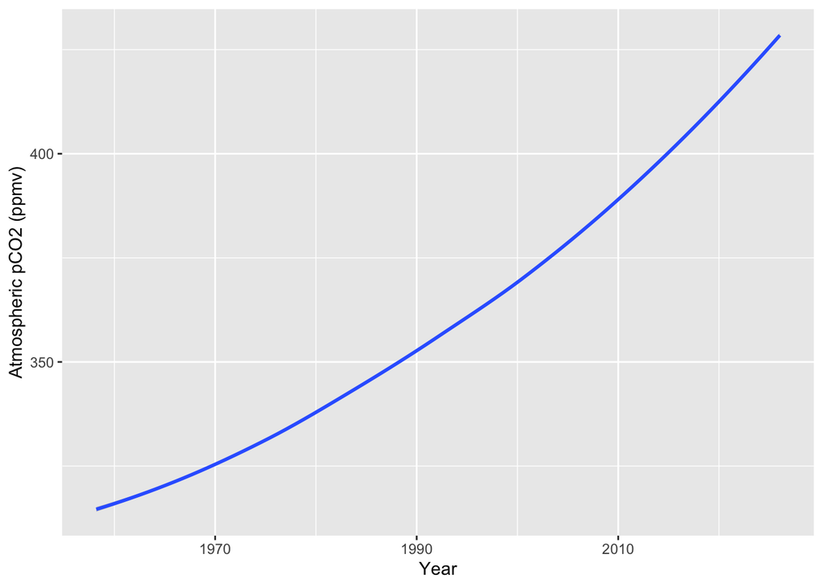

```r
co2 |> ggplot(aes(X3, X4)) +
  geom_smooth() +
  labs(x = "Year", y = "Atmospheric pCO2 (ppmv)")
```

What’s the annual cycle? Subtract the mean CO2 computed from each year. Compute the fractional part of th e year.

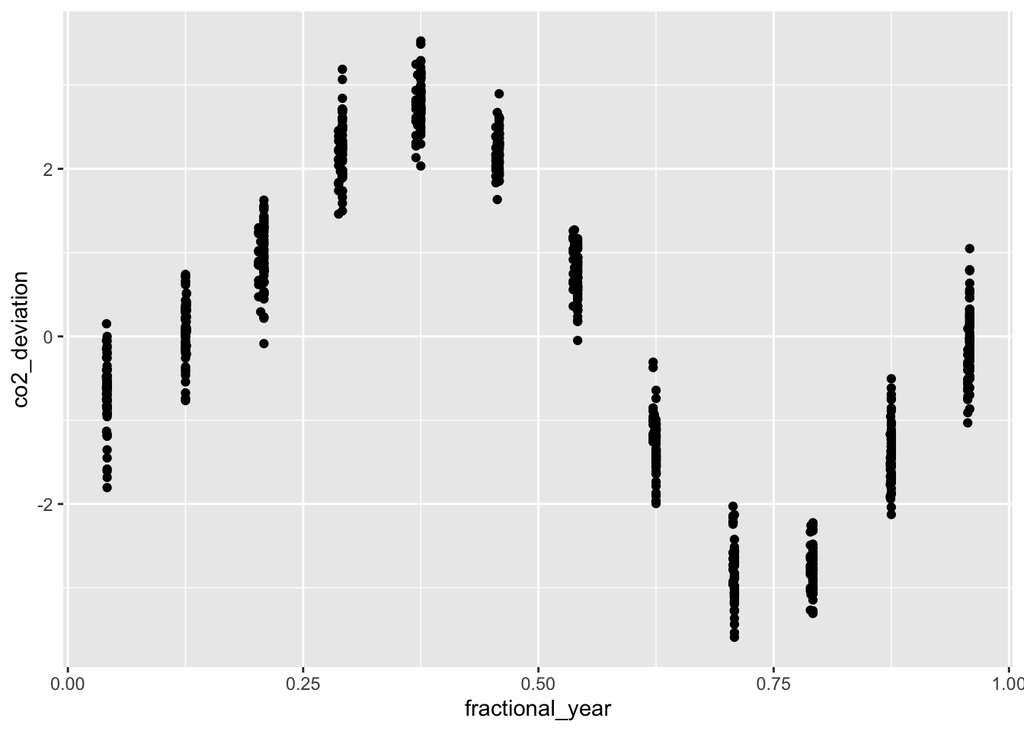

```r
co2 |> group_by(X1) |>
  mutate(fractional_year = X3 - X1,
         mean_co2 = mean(X4),
         co2_deviation = X4 - mean_co2) |>
  ungroup() |>
  ggplot(aes(fractional_year, co2_deviation)) +
  geom_point()
```

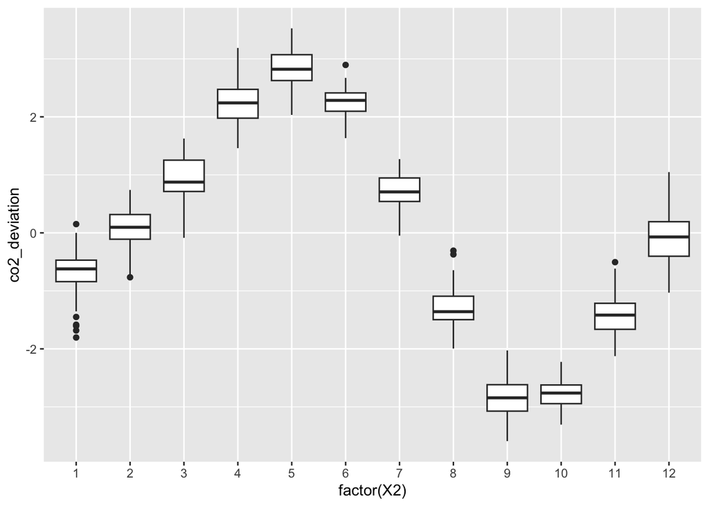

```r
co2_modified <- co2 |> group_by(X1) |>
  mutate(fractional_year = X3 - X1,
         mean_co2 = mean(X4),
         co2_deviation = X4 - mean_co2) |>
  ungroup()
co2_modified |>
  ggplot(aes(factor(X2), co2_deviation)) +
  geom_boxplot()
```

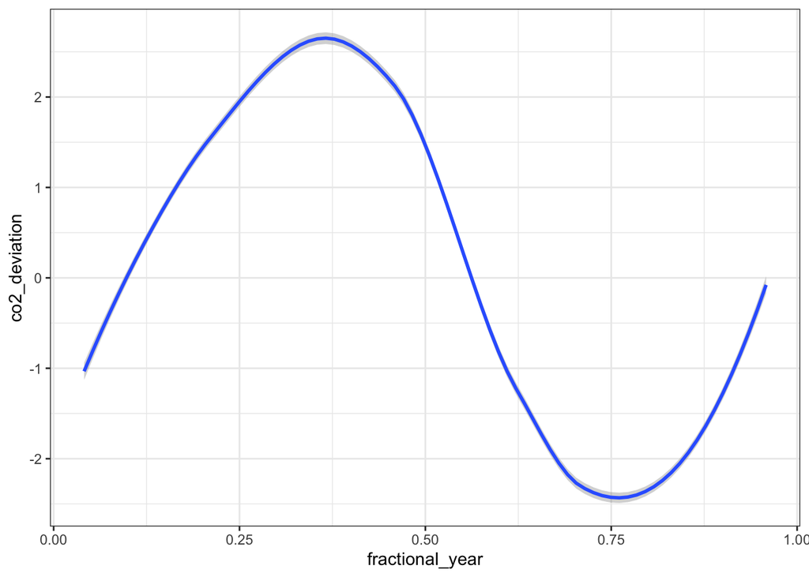

```r
co2_modified |>
  ggplot(aes(fractional_year, co2_deviation)) +
  geom_smooth() + theme_bw()
```

```r
lubridate::date_decimal(2022.10)
```

```
## [1] "2022-02-06 11:59:59 UTC"
```

```r
lubridate::date_decimal(2022.77)
```

```
## [1] "2022-10-09 01:11:59 UTC"
```

```r
lubridate::decimal_date(ymd("2022-10-11"))
```

```
## [1] 2022.775
```

Make a decade by decade plot

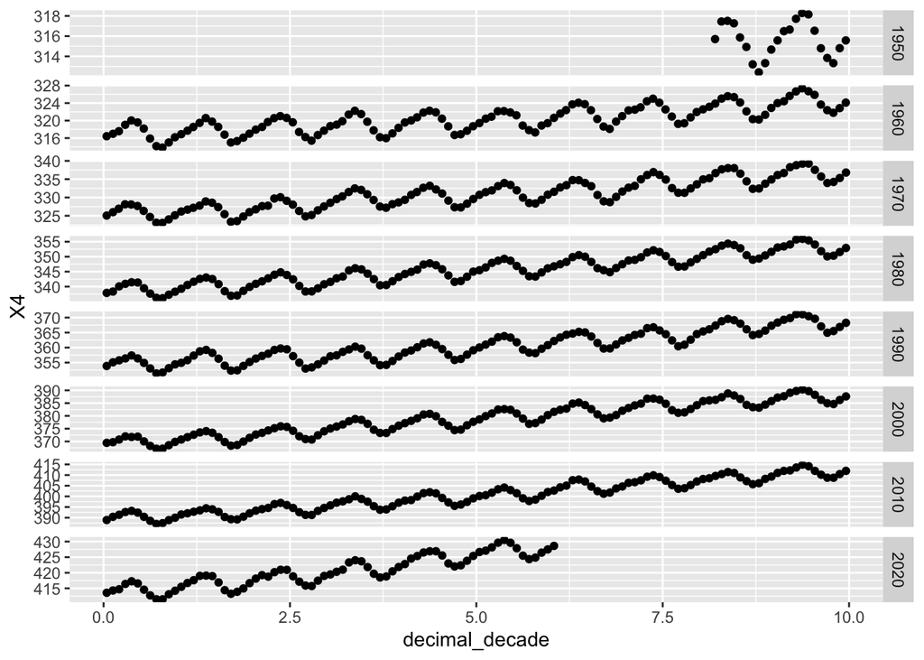

```r
co2 |> mutate(decade = 10*floor(X1/10),
              decimal_decade = X3 - decade) |>
  ggplot(aes(decimal_decade, X4)) +
  geom_point() +
  facet_grid(decade ~ . , scale = "free_y")
```

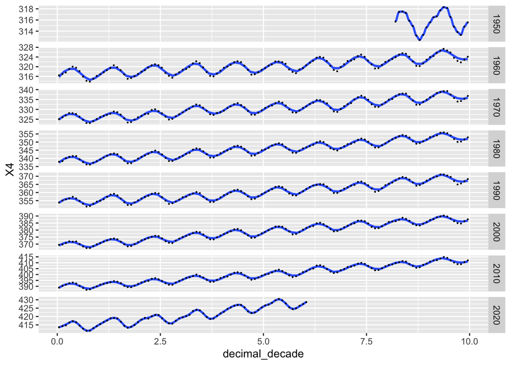

```r
co2 |> mutate(decade = 10*floor(X1/10),
              decimal_decade = X3 - decade) |>
  ggplot(aes(decimal_decade, X4)) +
  geom_smooth(method = "loess", span = 0.1) +
  geom_point(size = 0.2) +
  facet_grid(decade ~ . , scale = "free_y")
```

[output not shown]

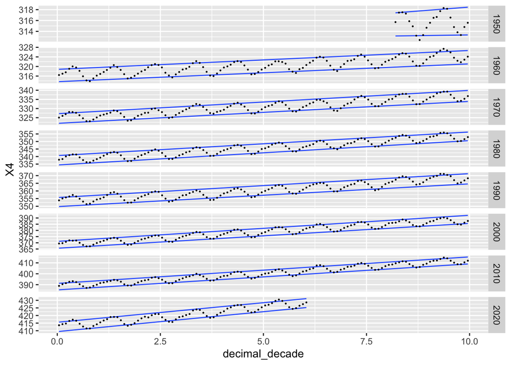

```r
co2 |> mutate(decade = 10*floor(X1/10),
              decimal_decade = X3 - decade) |>
  ggplot(aes(decimal_decade, X4)) +
  geom_quantile(quantiles = c(0.1, 0.9)) +
  geom_point(size = 0.2) +
  facet_grid(decade ~ . , scale = "free_y")
```

### GAM is just linear regression

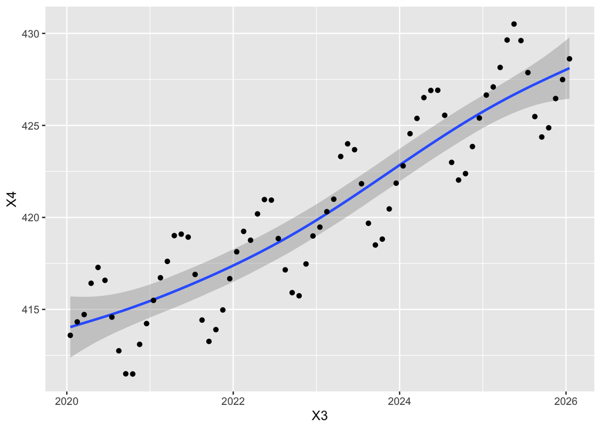

```r
co2 |> filter(X1 > 2019) |>
  ggplot(aes(X3, X4)) +
  geom_smooth(method = "gam", formula = y ~ s(x, bs = "cs")) +
  geom_point()
```

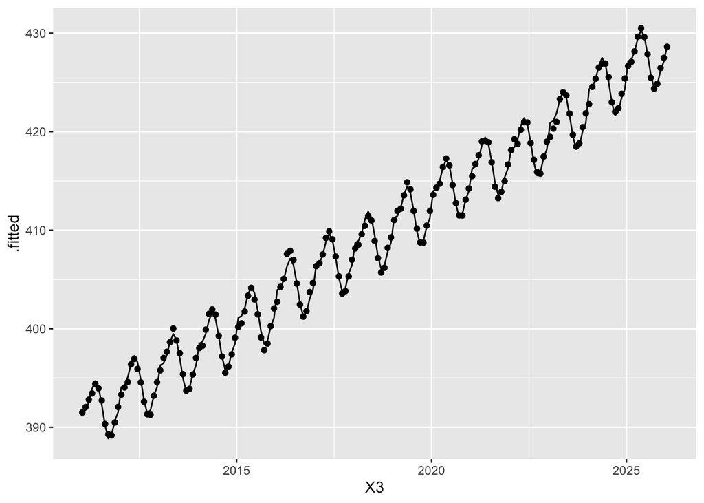

```r
gam1 <- mgcv::gam(X4 ~ s(dd, bs = "cc") + s(X1),
             data = co2 |> filter(X1 > 2010) |> mutate(dd = X3 - X1) )
broom::augment(gam1,
        co2 |> filter(X1 > 2010) ) |>
  ggplot() +
  geom_line(aes(X3, .fitted)) +
  geom_point(aes(X3, X4))
```